# Group 8 Term Project

Estimating the relationship between life satisfaction and marriage in BRFSS data; HEAL4008/STAT4803 — Public Health Data Analysis

Author

Logan Hughes, Sally Kim, Toluwalase Grace Ikubaje

# Introduction

> Our data analysis aims to understand the association between reported life satisfaction (LSATISFY) and reported marital status (RELATIONSHIP) among US adults. Life satisfaction has been consistently linked with physical health influencing health outcomes and health behaviours. Bi et al. (2022) found that the marital satisfaction was a predictor for life satisfaction that was positively associated with positive health outcomes. For example, individuals satisfied with their marriages reported a better physical health, lower odds of chronic illness, and lower rates of hospitalization (Bi et al., 2022). The relationship between marital status and life satisfaction has been extensively researched, with most studies finding a statistically significant correlation. Understanding the effects of marital status on life satisfaction is important for population health because of its impacts on physical, psychological, and social well-being. For example, married individuals in positive relationships were found to have lower mortality rates compared to those in unhappy marriages (Whisman et al., 2018).

> Mental health was also seen to be affected by marital status with Grundström et al. (2021) reporting that single and divorced individuals were at a higher risk of experiencing depressive symptoms and lower self-esteem, particularly among men. Hence, understanding the association between marital status and life satisfaction can help inform public health interventions and improve health outcomes. The objective of this research is to estimate the association between marital status and life satisfaction among the adults aged 18 years and older residing in the United States in 2022. A better understanding of this relationship, developing health interventions of support programs for divorced and single populations, and incorporating interventions to reduce marital dissatisfaction may aid in improving population health and reducing healthcare burden.

```r
# Packages
library(tidyr)
library(readxl)
library(dplyr)
library(ggplot2)
library(tableone)
library(skimr)
library(visdat)
library(DataExplorer)
library(kableExtra)
library(marginaleffects)
library(modelsummary)
library(labelled)
library(survey)
library(knitr)
library(broom)

# Set Seed
set.seed(3677658)
```

# Methods

## Data source and study population

> We use the Behavioural Risk Factor Surveillance System (BRFSS) survey as our dataset. It includes U.S. adults (age 18+) from the year 2022. For our analysis, the BRFSS dataset has been restricted to only our variables of interest to make dealing with the large set of data more manageable and efficient in R. Some states and territories have been identified which did not ask about life satisfaction, which is contributing to why there are many NA responses. We filter these states and territories out of the dataset to account for this. The full list of states and territories excluded from our analysis are: Arkansas, Colorado, Hawaii, Illinois, Louisiana, Maryland, Michigan, Nebraska, New York, North Dakota, Ohio, Oklahoma, Oregon, Pennsylvania, South Dakota, Virginia and Guam.

**Click to see more**

```r
# Check pathways
getwd()
```

```
[1] "/home/log/Desktop/Health_Data_Analytics/R/Labs"
```

```r
list.files("..")
```

```
[1] "Data"                     "HealhDataAnalytics.Rproj"
[3] "Labs"                     "term_project"
```

```r
list.files("../Data")
```

```
 [1] "asthma_adults.xlsx"          "BRFSS NY only_folder.xlsx"
 [3] "BRFSS NY only.xlsx"          "BRFSS NY only.xlsx.zip"
 [5] "BRFSS_113vars_data.xlsx"     "BRFSS_113vars_data.xlsx.zip"
 [7] "FARS_2022_person.csv"        "FARS_subset_v2.xlsx"
 [9] "FARS_subset.xlsx"            "Lab0_Birthweight_Data.xlsx"
[11] "Lab1_NHANES_Codebook.xlsx"   "Lab1_NHANES_Data.xlsx"
[13] "Lab10_Natality_Data.xlsx"    "Lab3_Natality_Dataset.xlsx"
[15] "Lab9_MEPS_data.xlsx"         "NAMCS_data.xlsx"
[17] "testBRFSS.xlsx"
```

```r
# Import edited BRFSS dataset
dat_raw <- read_excel("../Data/testBRFSS.xlsx")

dim(dat_raw)
```

```
[1] 445132     10
```

```r
names(dat_raw)
```

```
 [1] "_STATE"   "SEQNO"    "_LLCPWT"  "SEXVAR"   "_AGEG5YR" "MARITAL"
 [7] "CHILDREN" "LSATISFY" "INCOME3"  "_EDUCAG"
```

```r
# calculate missing states and make table
state_missing <- dat_raw %>%
  group_by(`_STATE`) %>%
  summarise(
    prop_missing = mean(is.na(LSATISFY)),
    n = n()
  )
state_missing %>% arrange(desc(prop_missing))
```

| _STATE | prop_missing | n |
| --- | --- | --- |
| 5 | 1.00000000 | 5309 |
| 8 | 1.00000000 | 9365 |
| 15 | 1.00000000 | 7747 |
| 17 | 1.00000000 | 4056 |
| 22 | 1.00000000 | 5629 |
| 24 | 1.00000000 | 16418 |
| 26 | 1.00000000 | 10058 |
| 31 | 1.00000000 | 7473 |
| 36 | 1.00000000 | 17800 |
| 38 | 1.00000000 | 4153 |

[output cut: 44 more lines]

```r
bad_states <- state_missing %>%
  filter(prop_missing == 1) %>%
  pull(`_STATE`)

# assign new dataset
dat <- dat_raw %>%
  filter(!(`_STATE` %in% bad_states))
```

## Variables

> The primary exposure is marital status (MARITAL) which was recoded to (RELATIONSHIP), which reports “Married/Dating”, “Divorced/Seperated”, “Widowed” and “Never married/Single”. The primary outcome is life satisfaction (LSATISFY) which was dichotomized into (LSATISFY2), reporting only satisfied or dissatisfied. This recoding was done to simplify our analysis and better address our research question. It also allows for plotting proportion satisfied, and for using a logistic regression model.

> To control for potential confounding, five covariates will be included in the model. These include sex (SEXVAR), age by groups (_AGE5YR), dependents (CHILDREN), level of education completed (_EDUCAG) and income (INCOME3). For income, we consolidate the income ranges into 3 categories meant to roughly represent lower, middle and upper income earners. Income and education are included to try and account for the effects of repsondents social economic status. Sex and age are commonly included covariates, and number of children is included as we believe it may be correlated with both life satisfaction and relationship status. We also use (_LLCPWT) for survey weighting.

> Each variable which had responses such as “Refused to answer” or “Don’t know” has been accounted for by recoding it as NA_character_ and being excluded from our analysis. We also have each report the survey response name instead of the number assigned to it. For our regression analysis, we would much prefer age to be continuous numerical data instead of categorical. To address this we create the (AGE5YRcont) variable, which assigns each age group an average of that groups age so that we can treat age as continuous. This is not perfect, but helps us better perform our regression analysis properly later. Labels are added to each variable to help with readability.

**Click to see more**

```r
# Recategorize lsatisfy into 2 groups satisfied or not satisfied
# Create a new variable called LSATISFY2, which just shows satisfied or dissatisfied
dat <- dat %>%
  mutate(
    LSATISFY2 = case_when(
      LSATISFY %in% c(1, 2) ~ "Satisfied",
      LSATISFY %in% c(3, 4) ~ "Dissatisfied",
      LSATISFY %in% c(7, 9) ~ NA_character_
    ),
    LSATISFY2 = factor(
      LSATISFY2,
      levels = c(
        "Satisfied",
        "Dissatisfied"
      )
    )
  )

# Recategorize MARITAL into 4 groups
# Create a new variable called RELATIONSHIP, which groups responses into in a relationship, separated/divorced, widowed, single/never married
dat <- dat %>%
  mutate(
    RELATIONSHIP = case_when(
      MARITAL %in% c(1,6) ~ "Married/Dating",
      MARITAL %in% c(2, 4) ~ "Divorced/Separated",
      MARITAL %in% c(3) ~ "Widowed",
      MARITAL %in% c(5) ~ "Never married/Single",
      MARITAL %in% c(9) ~ NA_character_
    ),
    RELATIONSHIP = factor(
      RELATIONSHIP,
      levels = c(
        "Married/Dating",
        "Divorced/Separated",
        "Widowed",
        "Never married/Single"
      )
    )
  )

# Recode _AGEG5YR to show range names instead of codes
# Create a new variable called AGEG5YRclear, which shows descriptions of the relevant BRFSS code responses
dat <- dat %>%
  mutate(
    AGEG5YRclear = case_when(
      `_AGEG5YR` %in% c(1) ~ "18-24",
      `_AGEG5YR` %in% c(2) ~ "25-29",
      `_AGEG5YR` %in% c(3) ~ "30-34",
      `_AGEG5YR` %in% c(4) ~ "35-39",
      `_AGEG5YR` %in% c(5) ~ "40-44",
      `_AGEG5YR` %in% c(6) ~ "45-49",
      `_AGEG5YR` %in% c(7) ~ "50-54",
      `_AGEG5YR` %in% c(8) ~ "55-59",
      `_AGEG5YR` %in% c(9) ~ "60-64",
      `_AGEG5YR` %in% c(10) ~ "65-69",
      `_AGEG5YR` %in% c(11) ~ "70-74",
      `_AGEG5YR` %in% c(12) ~ "75-79",
      `_AGEG5YR` %in% c(13) ~ "80+",
      `_AGEG5YR` %in% c(14) ~ NA_character_
    ),
    AGEG5YRclear = factor(
      AGEG5YRclear,
      levels = c(
      "18-24",
      "25-29",
      "30-34",
      "35-39",
      "40-44",
      "45-49",
      "50-54",
      "55-59",
      "60-64",
      "65-59",
      "70-74",
      "75-79",
      "80+"
      )
    )
  )

# Recode _AGEG5YR to try and get continuous age variable for regression
# Create a new variable called AGEG5YRcont, which shows descriptions of the relevant BRFSS code responses
dat <- dat %>%
  mutate(
    AGEG5YRcont = case_when(
      `_AGEG5YR` %in% c(1) ~ 22,
      `_AGEG5YR` %in% c(2) ~ 27,
      `_AGEG5YR` %in% c(3) ~ 32,
      `_AGEG5YR` %in% c(4) ~ 37,
      `_AGEG5YR` %in% c(5) ~ 42,
      `_AGEG5YR` %in% c(6) ~ 47,
      `_AGEG5YR` %in% c(7) ~ 52,
      `_AGEG5YR` %in% c(8) ~ 57,
      `_AGEG5YR` %in% c(9) ~ 62,
      `_AGEG5YR` %in% c(10) ~ 67,
      `_AGEG5YR` %in% c(11) ~ 72,
      `_AGEG5YR` %in% c(12) ~ 77,
      `_AGEG5YR` %in% c(13) ~ 85,
      `_AGEG5YR` %in% c(14) ~ NA_real_
    ),
  )

#Recoding INCOME3 to INCOME_new
# Create a new variable called INCOME_new, which groups ages into bigger ranges for communicating data takeaways later
dat <- dat %>%
  mutate(
    INCOME_new = case_when(
      `INCOME3` %in% c(1, 2, 3, 4, 5) ~ "Less than 35,000",
      `INCOME3` %in% c(6, 7, 8, 9) ~ "Between 35,000 and 100,000",
      `INCOME3` %in% c(9, 10, 11) ~ "100,000 and higher",
      `INCOME3` %in% c(77, 99) ~ NA_character_
    ),
    INCOME_new = factor(
      INCOME_new,
      levels = c(
        "Between 35,000 and 100,000",
        "Less than 35,000",
        "100,000 and higher"
      )
    )
  )

# Recoding SEXVAR to show more clearly male or female for data vis.
# Create a new variable called SEXVAR2, which reports male or female instead of 1 or 2
dat <- dat %>%
  mutate(
    SEXVAR2 = case_when(
      SEXVAR %in% c(1) ~ "Male",
      SEXVAR %in% c(2) ~ "Female"
    ),
    SEXVAR2 = factor(
      SEXVAR2,
      levels = c(
        "Male",
        "Female"
      )
    )
  )

#Recoding _EDUCAG into EDUC
# Create a new variable called EDUC, which relabels the output to more clearly communicate data. also recodes 9 as NA
dat <- dat %>%
  mutate(
    EDUC = case_when(
      `_EDUCAG` %in% c(1) ~ "Did not graduate Highschool",
      `_EDUCAG` %in% c(2) ~ "Graduated Highschool",
      `_EDUCAG` %in% c(3) ~ "Attended College or Technical School",
      `_EDUCAG` %in% c(4) ~ "Graduated College or Technical School",
      `_EDUCAG` %in% c(9) ~ NA_character_
    ),
    EDUC = factor(
      EDUC,
      levels = c(
        "Graduated Highschool",
        "Did not graduate Highschool",
        "Attended College or Technical School",
        "Graduated College or Technical School"
      )
    )
  )

# Recoding CHILDREN to account for NA responses
# Create a new variable called CHILDREN2, which just shows has kids or doesn't
dat <- dat %>%
  mutate(
    CHILDREN2 = case_when(
      CHILDREN %in% c(1:87) ~ "Has Children",
      CHILDREN %in% c(88) ~ "No Children",
      CHILDREN %in% c(99) ~ NA_character_
    ),
    CHILDREN2 = factor(
      CHILDREN2,
      levels = c(
        "No Children",
        "Has Children"
      )
    )
  )
```

```r
# labelling all variables
var_label(dat) <- list(
  LSATISFY2 = "Life Satisfaction",
  RELATIONSHIP = "Relationship Status",
  AGEG5YRclear = "Age Groups",
  AGEG5YRcont = "Age as Continuous",
  INCOME_new = "Income",
  EDUC = "Level of Education",
  CHILDREN2 = "Children",
  SEXVAR2 = "Sex"
)
```

```r
# Create survey weighting using _LLCPWT
svy_design <- svydesign(
  ids = ~1,
  weights = ~`_LLCPWT`,
  data = dat
)
```

# Statistical Analysis

## Exploratory Data Analysis

> Scatterplots and boxplots were created to compare relationship status and life satisfaction among the various age groups. Due to the large number of observations in the data set, the plots were not as useful as we hoped. To help with EDA, we plotted the proportion of people reporting being satisfied with their life and stratified this by age. In this unadjusted comparison, we can see a relationship between age and life satisfaction, as older individuals report higher life satisfaction than younger individuals in most groups. We also the differences between groups in reported life satisfaction shrink as age increases. Notably, when we tested dating and married seperate, they were quite close and so we grouped them together to better represent our question of in a relationship vs. not in a relationship. Also note that life satisfaction among the married/dating group is less variable with age than other groups. From this EDA, the association between marital status and life satisfaction appears to vary across age groups, suggesting possible effect modification by age. This is accounted for in our modeling later.

**Click to see more**

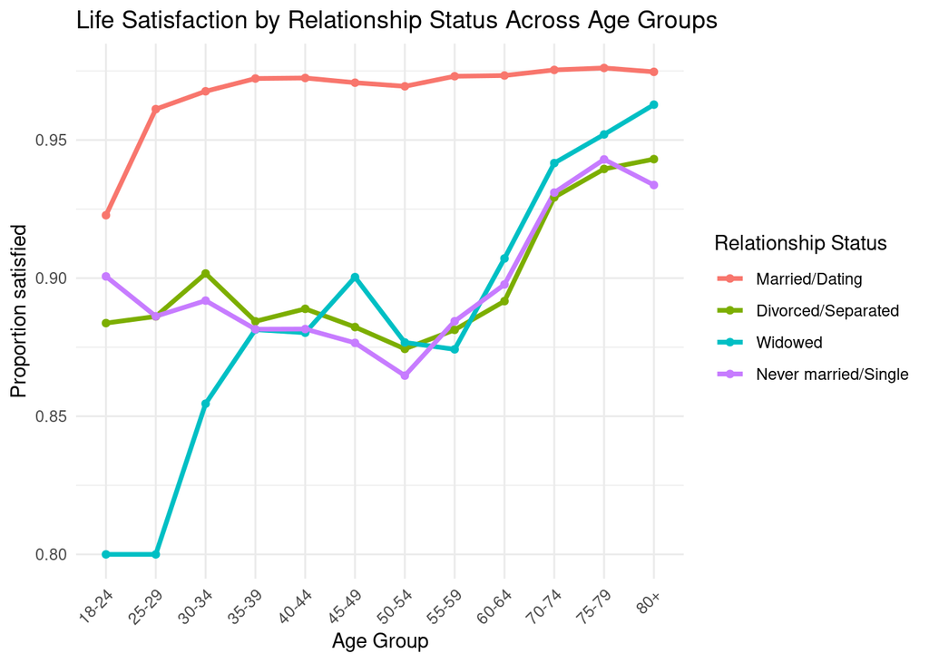

```r
# plotting proportion satisfied within age groups, stratified by age (using dat) for EDA
plotdat <- dat %>%
  filter(!is.na(LSATISFY2), !is.na(RELATIONSHIP), !is.na(AGEG5YRclear)) %>%
  group_by(AGEG5YRclear, RELATIONSHIP) %>%
  summarise(
    prop_satisfied = mean(LSATISFY2 == "Satisfied"),
    n = n(),
    .groups = "drop"
  )

ggplot(plotdat,
       aes(x = AGEG5YRclear,
           y = prop_satisfied,
           color = RELATIONSHIP,
           group = RELATIONSHIP)) +
  geom_line(size = 1.2) +
  geom_point() +
  labs(
    x = "Age Group",
    y = "Proportion satisfied",
    color = "Relationship Status",
    title = "Life Satisfaction by Relationship Status Across Age Groups"
  ) +
  theme_minimal() +
  theme(axis.text.x = element_text(angle = 45, hjust = 1))
```

## Modeling

> We compare 3 models, and report odds ratios and confidence intervals for each. First we fit a unadjusted logistic regression with no covariates, then a model with covariates and an interaction with age. We then run a similar adjusted model but using a surveyweighted model. For this model, svy_lr_adj_int, we also report risk ratios and risk differences by relationship. We then graph these risk ratios across age.

> The primary exposure in the adjusted models is marital status, and we set the reference for it to married, since married reported the highest unadjusted life satisfaction in our EDA. For covariates references we arbitrarily assign male as the reference for (SEXVAR2), we select no children for (CHILDREN2), we select graduated highschool for (EDUC) and finally select income between 35,000 and 100,000 for (INCOME_new). We treat age as a interaction in our adjusted models.

# Results

## Table 1, using recoded variables, survey weights and reporting SMD

> Table 1 is created to get a broad overview of our sample characteristics, stratified by relationship status. We report SMD to compare variables easier.

```r
# variables of interest
vars <- c("LSATISFY2", "SEXVAR2", "AGEG5YRclear", "CHILDREN2", "EDUC", "INCOME_new")
factorVars <- c("LSATISFY2", "SEXVAR2", "AGEG5YRclear", "CHILDREN2", "EDUC", "INCOME_new")

table1_survey <- svyCreateTableOne(
            vars = vars,
            strata = "RELATIONSHIP",
            data = svy_design,
            factorVars = factorVars,
            addOverall = TRUE)

# kableExtra to make presentation nicer
print(table1_survey,
      showAllLevels = TRUE,
      quote = FALSE,
      noSpaces = TRUE,
      smd = TRUE,
      varLabels = TRUE,
      printToggle = FALSE) |>
  kable() |>
  kable_styling(bootstrap_options = c("striped", "condensed", "responsive"),
                font_size = 11,
                full_width = TRUE)
```

|  | level | Overall | Married/Dating | Divorced/Separated | Widowed | Never married/Single | p | test | SMD |
| --- | --- | --- | --- | --- | --- | --- | --- | --- | --- |
| n |  | 178734084.0 | 97700926.2 | 22821563.4 | 12416457.8 | 43551807.0 |  |  |  |
| Life Satisfaction (%) | Satisfied | 126512511.9 (93.9) | 72571308.9 (96.8) | 15646588.9 (89.6) | 9264754.5 (93.7) | 27899499.5 (89.3) | <0.001 |  | 0.174 |
|  | Dissatisfied | 8278961.1 (6.1) | 2421672.5 (3.2) | 1808408.4 (10.4) | 624570.7 (6.3) | 3351051.9 (10.7) |  |  |  |
| Sex (%) | Male | 87088902.7 (48.7) | 49018158.1 (50.2) | 9988470.4 (43.8) | 3234367.2 (26.0) | 23652338.5 (54.3) | <0.001 |  | 0.319 |
|  | Female | 91645181.3 (51.3) | 48682768.1 (49.8) | 12833093.1 (56.2) | 9182090.7 (74.0) | 19899468.5 (45.7) |  |  |  |
| Age Groups (%) | 18-24 | 21501772.3 (13.2) | 3889082.8 (4.4) | 321732.0 (1.6) | 52259.6 (0.5) | 16949146.4 (40.3) | <0.001 |  | 1.596 |
|  | 25-29 | 13831244.0 (8.5) | 5760873.4 (6.5) | 691586.0 (3.4) | 51712.4 (0.5) | 7136152.7 (17.0) |  |  |  |
|  | 30-34 | 16833725.5 (10.4) | 9379839.4 (10.7) | 1457360.0 (7.2) | 117682.6 (1.1) | 5687401.9 (13.5) |  |  |  |
|  | 35-39 | 13710417.6 (8.4) | 8954797.3 (10.2) | 1592414.0 (7.8) | 114193.3 (1.1) | 2917260.4 (6.9) |  |  |  |
|  | 40-44 | 15038431.0 (9.3) | 9950260.5 (11.3) | 2306916.1 (11.4) | 141637.9 (1.3) | 2536019.4 (6.0) |  |  |  |
|  | 45-49 | 11781731.6 (7.2) | 7854334.2 (8.9) | 2134404.5 (10.5) | 219966.3 (2.1) | 1483458.8 (3.5) |  |  |  |
|  | 50-54 | 13821145.7 (8.5) | 9094570.9 (10.3) | 2742868.5 (13.5) | 374720.4 (3.5) | 1523058.8 (3.6) |  |  |  |
|  | 55-59 | 13035593.1 (8.0) | 8309554.1 (9.4) | 2641541.4 (13.0) | 602783.3 (5.6) | 1399547.7 (3.3) |  |  |  |
|  | 60-64 | 15196855.7 (9.4) | 9774017.3 (11.1) | 2900477.9 (14.3) | 1123996.3 (10.5) | 1302324.8 (3.1) |  |  |  |
|  | 70-74 | 11283094.4 (6.9) | 6940047.8 (7.9) | 1680054.9 (8.3) | 1974655.3 (18.5) | 600410.4 (1.4) |  |  |  |
|  | 75-79 | 7736378.1 (4.8) | 4403429.5 (5.0) | 1013276.3 (5.0) | 1982110.9 (18.5) | 315825.0 (0.8) |  |  |  |
|  | 80+ | 8756325.6 (5.4) | 3722920.8 (4.2) | 804101.2 (4.0) | 3935089.6 (36.8) | 238301.4 (0.6) |  |  |  |
| Children (%) | No Children | 113841653.3 (66.8) | 56206301.5 (60.3) | 15630966.7 (71.4) | 10757437.6 (89.6) | 30140050.1 (72.3) | <0.001 |  | 0.358 |
|  | Has Children | 56459039.6 (33.2) | 37030855.8 (39.7) | 6269021.5 (28.6) | 1255051.0 (10.4) | 11541426.4 (27.7) |  |  |  |
| Level of Education (%) | Graduated Highschool | 48095330.0 (27.1) | 22468045.9 (23.1) | 6288403.9 (27.6) | 3944494.2 (31.9) | 14936267.9 (34.4) | <0.001 |  | 0.281 |
|  | Did not graduate Highschool | 21793047.2 (12.3) | 10659754.3 (11.0) | 3727365.3 (16.4) | 2381170.4 (19.3) | 4817924.6 (11.1) |  |  |  |
|  | Attended College or Technical School | 54450470.9 (30.7) | 28754420.3 (29.6) | 7674526.6 (33.7) | 3745882.5 (30.3) | 13784313.3 (31.7) |  |  |  |
|  | Graduated College or Technical School | 53261306.8 (30.0) | 35416903.1 (36.4) | 5067441.2 (22.3) | 2285897.5 (18.5) | 9880496.0 (22.8) |  |  |  |
| Income (%) | Between 35,000 and 100,000 | 74699412.6 (55.4) | 45846696.7 (60.0) | 8428023.4 (46.1) | 3633872.3 (42.5) | 16442267.4 (53.1) | <0.001 |  | 0.478 |
|  | Less than 35,000 | 40541359.8 (30.0) | 14620965.4 (19.1) | 8825756.7 (48.2) | 4668156.4 (54.6) | 12132169.6 (39.1) |  |  |  |
|  | 100,000 and higher | 19705455.9 (14.6) | 15927621.9 (20.8) | 1046868.4 (5.7) | 244516.6 (2.9) | 2418584.3 (7.8) |  |  |  |

> Life satisfaction is highest among the married dating group at 96.8% of the survey weighted dataset reporting satisfied, supporting its use as the reference group in our analysis. Divorced/Seperated are at 89.6% reporting satisfied, which is similar to Never married/single at 89.3%. Widowed report higher at 93.7%.

> 55% of our survey weighted dataset is in the “middle” income group, supporting its use as the reference for income. The same is true for the children group, as it the percentage supports no children as the reference.

## Figure 1

> Figure 1. shows the percentage of people reporting that they are dissatisfied (as it is easier to read due to the smaller size) on the X axis, by their relationship status in the Y axis. This figure helps us see the gross association between the exposure and the outcome before adjusting for other variables when we model the relationship later.

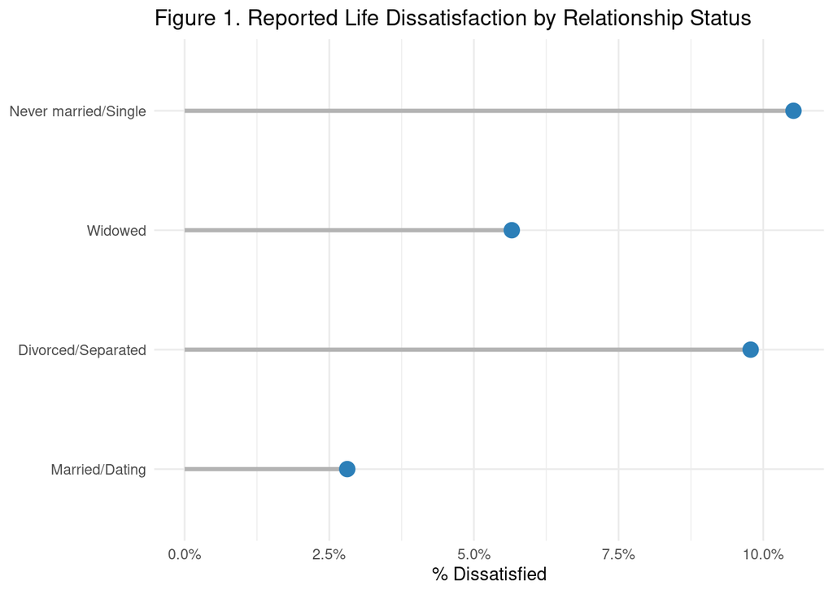

```r
fig1_dat <- dat %>% filter(!is.na(LSATISFY2), !is.na(RELATIONSHIP)) %>% group_by(RELATIONSHIP) %>% summarise( prop_dissatisfied = mean(LSATISFY2 == "Dissatisfied"), n = n(), .groups = "drop" )

ggplot(fig1_dat,
       aes(x = RELATIONSHIP,
           y = prop_dissatisfied)) +

  geom_segment(aes(xend = RELATIONSHIP,
                   y = 0,
                   yend = prop_dissatisfied),
               color = "gray70",
               linewidth = 1.2) +

  coord_flip() +

  geom_point(size = 4, color = "#2C7FB8") +

  scale_y_continuous(labels = scales::percent_format()) +

  labs(
    title = "Figure 1. Reported Life Dissatisfaction by Relationship Status",
    x = NULL,
    y = "% Dissatisfied"
  ) +

  theme_minimal()
```

> Here we see that the never married/single and divorced/seperated groups have the highest percent reporting life dissatisfaction. Widowed report significantly less dissatisfaction, and then married report the least dissatisfaction. This matches what we see from our table1 outcomes.

> We now run our models and go over the results.

## Unadjusted Model

```r
log_unadj <- glm (LSATISFY2 ~ RELATIONSHIP,
                              data = dat,
                              family = binomial(link = "logit"))

# Tidy model output
unadj_tbl <- tidy(log_unadj, conf.int = TRUE, exponentiate = TRUE) %>%
  mutate(across(where(is.numeric), round, 3)) %>%
  rename(
    Term = term,
    OR = estimate,
    CI_low = conf.low,
    CI_high = conf.high,
    p_value = p.value
  )

# Print table
kbl(unadj_tbl,
    caption = "Table 2. Unadjusted logistic regression (Odds Ratios)",
    align = "lccccc") %>%
  kable_styling(
    bootstrap_options = c("striped", "condensed", "responsive"),
    full_width = FALSE
  )
```

Table 2. Unadjusted logistic regression (Odds Ratios)

| Term | OR | std.error | statistic | p_value | CI_low | CI_high |
| --- | --- | --- | --- | --- | --- | --- |
| (Intercept) | 0.029 | 0.016 | -220.655 | 0 | 0.028 | 0.030 |
| RELATIONSHIPDivorced/Separated | 3.750 | 0.024 | 55.874 | 0 | 3.580 | 3.928 |
| RELATIONSHIPWidowed | 2.073 | 0.031 | 23.837 | 0 | 1.952 | 2.200 |
| RELATIONSHIPNever married/Single | 4.067 | 0.023 | 62.164 | 0 | 3.891 | 4.251 |

## Adjusted Model with covariates and age (estimated continuous) interacting with relationship status

```r
log_adj_int <- glm (LSATISFY2 ~ RELATIONSHIP * AGEG5YRcont + SEXVAR2 + CHILDREN2 + EDUC + INCOME_new,
                            data = dat,
                            family = binomial(link = "logit"))

adj_int_tbl <- tidy(log_adj_int, conf.int = TRUE, exponentiate = TRUE) %>%
  mutate(across(where(is.numeric), round, 3)) %>%
  rename(
    Term = term,
    OR = estimate,
    CI_low = conf.low,
    CI_high = conf.high,
    p_value = p.value
  )

kbl(adj_int_tbl,
    caption = "Table 3. Adjusted model with interaction (Odds Ratios)",
    align = "lccccc") %>%
  kable_styling(
    bootstrap_options = c("striped", "condensed", "responsive"),
    full_width = FALSE
  )
```

Table 3. Adjusted model with interaction (Odds Ratios)

| Term | OR | std.error | statistic | p_value | CI_low | CI_high |
| --- | --- | --- | --- | --- | --- | --- |
| (Intercept) | 0.072 | 0.070 | -37.792 | 0.000 | 0.063 | 0.082 |
| RELATIONSHIPDivorced/Separated | 3.902 | 0.100 | 13.615 | 0.000 | 3.207 | 4.746 |
| RELATIONSHIPWidowed | 8.971 | 0.183 | 11.967 | 0.000 | 6.248 | 12.822 |
| RELATIONSHIPNever married/Single | 1.676 | 0.078 | 6.617 | 0.000 | 1.439 | 1.954 |
| AGEG5YRcont | 0.985 | 0.001 | -13.503 | 0.000 | 0.983 | 0.987 |
| SEXVAR2Female | 0.896 | 0.021 | -5.331 | 0.000 | 0.860 | 0.933 |
| CHILDREN2Has Children | 0.710 | 0.027 | -12.494 | 0.000 | 0.673 | 0.749 |
| EDUCDid not graduate Highschool | 1.093 | 0.040 | 2.212 | 0.027 | 1.010 | 1.182 |
| EDUCAttended College or Technical School | 1.131 | 0.026 | 4.765 | 0.000 | 1.075 | 1.190 |
| EDUCGraduated College or Technical School | 0.842 | 0.028 | -6.203 | 0.000 | 0.797 | 0.889 |
| INCOME_newLess than 35,000 | 2.407 | 0.023 | 38.650 | 0.000 | 2.302 | 2.517 |
| INCOME_new100,000 and higher | 0.508 | 0.053 | -12.846 | 0.000 | 0.457 | 0.562 |
| RELATIONSHIPDivorced/Separated:AGEG5YRcont | 0.993 | 0.002 | -4.005 | 0.000 | 0.990 | 0.996 |
| RELATIONSHIPWidowed:AGEG5YRcont | 0.977 | 0.003 | -8.580 | 0.000 | 0.972 | 0.983 |
| RELATIONSHIPNever married/Single:AGEG5YRcont | 1.007 | 0.002 | 4.798 | 0.000 | 1.004 | 1.010 |

## Survey-weighted model

```r
svy_lr_adj_int <- svyglm(
  LSATISFY2 ~ RELATIONSHIP * AGEG5YRcont + SEXVAR2 + CHILDREN2 + EDUC + INCOME_new,
  design = svy_design,
  family = quasibinomial(link='logit')
)

# Odds ratios and 95% CI
OR <- exp(coef(svy_lr_adj_int))
CI <- exp(confint(svy_lr_adj_int))

svy_tbl <- tidy(svy_lr_adj_int, conf.int = TRUE, exponentiate = TRUE) %>%
  mutate(across(where(is.numeric), round, 3)) %>%
  rename(
    Term = term,
    OR = estimate,
    CI_low = conf.low,
    CI_high = conf.high,
    p_value = p.value
  )

kbl(svy_tbl,
    caption = "Table 4. Survey-weighted logistic regression (Odds Ratios)",
    align = "lccccc") %>%
  kable_styling(
    bootstrap_options = c("striped", "condensed", "responsive"),
    full_width = FALSE
  )
```

Table 4. Survey-weighted logistic regression (Odds Ratios)

| Term | OR | std.error | statistic | p_value | CI_low | CI_high |
| --- | --- | --- | --- | --- | --- | --- |
| (Intercept) | 0.082 | 0.164 | -15.267 | 0.000 | 0.059 | 0.113 |
| RELATIONSHIPDivorced/Separated | 2.018 | 0.196 | 3.590 | 0.000 | 1.376 | 2.961 |
| RELATIONSHIPWidowed | 5.875 | 0.359 | 4.929 | 0.000 | 2.905 | 11.881 |
| RELATIONSHIPNever married/Single | 1.478 | 0.178 | 2.199 | 0.028 | 1.043 | 2.094 |
| AGEG5YRcont | 0.982 | 0.003 | -7.089 | 0.000 | 0.978 | 0.987 |
| SEXVAR2Female | 0.938 | 0.049 | -1.290 | 0.197 | 0.852 | 1.034 |
| CHILDREN2Has Children | 0.673 | 0.064 | -6.224 | 0.000 | 0.594 | 0.763 |
| EDUCDid not graduate Highschool | 1.252 | 0.085 | 2.656 | 0.008 | 1.061 | 1.478 |
| EDUCAttended College or Technical School | 1.173 | 0.058 | 2.742 | 0.006 | 1.046 | 1.314 |
| EDUCGraduated College or Technical School | 0.838 | 0.061 | -2.885 | 0.004 | 0.743 | 0.945 |
| INCOME_newLess than 35,000 | 2.260 | 0.050 | 16.405 | 0.000 | 2.050 | 2.491 |
| INCOME_new100,000 and higher | 0.518 | 0.101 | -6.511 | 0.000 | 0.425 | 0.631 |
| RELATIONSHIPDivorced/Separated:AGEG5YRcont | 1.004 | 0.004 | 1.157 | 0.247 | 0.997 | 1.011 |
| RELATIONSHIPWidowed:AGEG5YRcont | 0.983 | 0.005 | -3.213 | 0.001 | 0.972 | 0.993 |
| RELATIONSHIPNever married/Single:AGEG5YRcont | 1.009 | 0.004 | 2.646 | 0.008 | 1.002 | 1.016 |

```r
# Create datasets for each exposure group
df_married <- dat
df_divsep <- dat
df_widowed <- dat
df_single <- dat

# Set everyone to each group
df_married$RELATIONSHIP <- "Married/Dating"
df_divsep$RELATIONSHIP <- "Divorced/Separated"
df_widowed$RELATIONSHIP <- "Widowed"
df_single$RELATIONSHIP <- "Never married/Single"

# Predict probabilities (survey-weighted model)
p_married <- predict(svy_lr_adj_int, newdata = df_married, type = "response")
p_divsep <- predict(svy_lr_adj_int, newdata = df_divsep, type = "response")
p_widowed <- predict(svy_lr_adj_int, newdata = df_widowed, type = "response")
p_single <- predict(svy_lr_adj_int, newdata = df_single, type = "response")

# Average predicted probabilities
mean_married <- mean(p_married)
mean_divsep <- mean(p_divsep)
mean_widowed <- mean(p_widowed)
mean_single <- mean(p_single)

# Risk Ratios (vs Married)
RR_divsep <- mean_divsep / mean_married
RR_widowed <- mean_widowed / mean_married
RR_single <- mean_single / mean_married

# Risk Differences (vs Married)
RD_divsep <- mean_divsep - mean_married
RD_widowed <- mean_widowed - mean_married
RD_single <- mean_single - mean_married

# Combine results into a table
risk_results <- tibble(
  Group = c("Married/Dating", "Divorced/Separated", "Widowed", "Never married/Single"),
  Risk = c(mean_married, mean_divsep, mean_widowed, mean_single),
  Risk_Ratio = c(1, RR_divsep, RR_widowed, RR_single),
  Risk_Difference = c(0, RD_divsep, RD_widowed, RD_single)
)

# Print table
risk_results_fmt <- risk_results %>%
  mutate(across(where(is.numeric), round, 3))

kbl(
  risk_results_fmt,
  caption = "Table 5. Marginal risks, risk ratios, and risk differences",
  align = "lccc"
) %>%
  kable_styling(
    bootstrap_options = c("striped", "condensed", "responsive"),
    full_width = FALSE,
    font_size = 11
  )
```

Table 5. Marginal risks, risk ratios, and risk differences

| Group | Risk | Risk_Ratio | Risk_Difference |
| --- | --- | --- | --- |
| Married/Dating | 0.035 | 1.000 | 0.000 |
| Divorced/Separated | 0.081 | 2.335 | 0.046 |
| Widowed | 0.081 | 2.322 | 0.046 |
| Never married/Single | 0.079 | 2.271 | 0.044 |

```r
ages <- seq(20, 80, by = 1)

results_list <- lapply(ages, function(a) {

  df_married$AGEG5YRcont <- a
  df_divsep$AGEG5YRcont  <- a
  df_widowed$AGEG5YRcont <- a
  df_single$AGEG5YRcont  <- a

  # Recompute predictions at each age
  p_married <- predict(svy_lr_adj_int, newdata = df_married, type = "response")
  p_divsep  <- predict(svy_lr_adj_int, newdata = df_divsep, type = "response")
  p_widowed <- predict(svy_lr_adj_int, newdata = df_widowed, type = "response")
  p_single  <- predict(svy_lr_adj_int, newdata = df_single, type = "response")

  mean_married <- mean(p_married)
  mean_divsep  <- mean(p_divsep)
  mean_widowed <- mean(p_widowed)
  mean_single  <- mean(p_single)

  # Return one row
  data.frame(
    age = a,
    RR_divsep  = mean_divsep / mean_married,
    RR_widowed = mean_widowed / mean_married,
    RR_single  = mean_single / mean_married
  )
})

# Bind into one dataset
results <- do.call(rbind, results_list)

# kableextra table
kbl(results %>% mutate(across(where(is.numeric), round, 3)),
    caption = "Table 6. Risk ratios by age",
    align = "lccc") %>%
  kable_styling(full_width = FALSE)
```

Table 6. Risk ratios by age

| age | RR_divsep | RR_widowed | RR_single |
| --- | --- | --- | --- |
| 20 | 2.004 | 3.349 | 1.678 |
| 21 | 2.014 | 3.315 | 1.693 |
| 22 | 2.023 | 3.281 | 1.708 |
| 23 | 2.033 | 3.247 | 1.724 |
| 24 | 2.043 | 3.212 | 1.739 |
| 25 | 2.052 | 3.177 | 1.755 |
| 26 | 2.062 | 3.142 | 1.771 |
| 27 | 2.072 | 3.107 | 1.787 |
| 28 | 2.082 | 3.072 | 1.804 |
| 29 | 2.092 | 3.037 | 1.820 |
| 30 | 2.102 | 3.001 | 1.837 |
| 31 | 2.112 | 2.966 | 1.854 |
| 32 | 2.122 | 2.930 | 1.871 |
| 33 | 2.132 | 2.895 | 1.888 |
| 34 | 2.142 | 2.860 | 1.906 |
| 35 | 2.153 | 2.824 | 1.923 |
| 36 | 2.163 | 2.789 | 1.941 |
| 37 | 2.173 | 2.753 | 1.959 |
| 38 | 2.184 | 2.718 | 1.977 |
| 39 | 2.194 | 2.683 | 1.995 |
| 40 | 2.204 | 2.648 | 2.014 |
| 41 | 2.215 | 2.613 | 2.032 |
| 42 | 2.226 | 2.578 | 2.051 |
| 43 | 2.236 | 2.544 | 2.070 |
| 44 | 2.247 | 2.509 | 2.090 |
| 45 | 2.257 | 2.475 | 2.109 |
| 46 | 2.268 | 2.441 | 2.129 |
| 47 | 2.279 | 2.407 | 2.149 |
| 48 | 2.290 | 2.373 | 2.169 |
| 49 | 2.300 | 2.340 | 2.189 |
| 50 | 2.311 | 2.306 | 2.210 |
| 51 | 2.322 | 2.273 | 2.230 |
| 52 | 2.333 | 2.241 | 2.251 |
| 53 | 2.344 | 2.208 | 2.273 |
| 54 | 2.355 | 2.176 | 2.294 |
| 55 | 2.366 | 2.144 | 2.315 |
| 56 | 2.378 | 2.113 | 2.337 |
| 57 | 2.389 | 2.081 | 2.359 |
| 58 | 2.400 | 2.050 | 2.382 |
| 59 | 2.411 | 2.019 | 2.404 |
| 60 | 2.423 | 1.989 | 2.427 |
| 61 | 2.434 | 1.959 | 2.450 |
| 62 | 2.446 | 1.929 | 2.473 |
| 63 | 2.457 | 1.900 | 2.496 |
| 64 | 2.469 | 1.870 | 2.520 |
| 65 | 2.480 | 1.841 | 2.544 |
| 66 | 2.492 | 1.813 | 2.568 |
| 67 | 2.503 | 1.785 | 2.592 |
| 68 | 2.515 | 1.757 | 2.617 |
| 69 | 2.527 | 1.729 | 2.642 |
| 70 | 2.539 | 1.702 | 2.667 |
| 71 | 2.550 | 1.675 | 2.692 |
| 72 | 2.562 | 1.649 | 2.718 |
| 73 | 2.574 | 1.623 | 2.743 |
| 74 | 2.586 | 1.597 | 2.770 |
| 75 | 2.598 | 1.571 | 2.796 |
| 76 | 2.610 | 1.546 | 2.823 |
| 77 | 2.622 | 1.521 | 2.850 |
| 78 | 2.634 | 1.497 | 2.877 |
| 79 | 2.647 | 1.472 | 2.904 |
| 80 | 2.659 | 1.449 | 2.932 |

## Regression results

> In the unadjusted model, all non-married/dating groups had higher odds of reporting life dissatisfaction compared to those who were married or dating. The strongest association was observed among never married/single individuals (OR ≈ 4.07 with 95%CI: (3.89,4.25)), followed by divorced/separated (OR ≈ 3.75 with 95%CI: (3.58,3.93)) and widowed individuals (OR ≈ 2.07 with 95%CI: (1.95,2.20)).

> After adjusting for age, sex, children, education, and income, these associations changed but remained statistically significant. In the fully adjusted survey-weighted model, divorced or separated individuals had approximately twice the odds of life dissatisfaction compared to married or dating individuals (OR = 2.02, 95% CI: (1.38,2.96). Widowed individuals showed the strongest association (OR = 5.88, 95% CI: (2.91,11.88)), while never married/single individuals also remained at higher odds (OR = 1.48, 95% CI: (1.04,2.09)).

> The age interaction in the model suggest the association between relationship status and life satisfaction/dissatisfction changes as you age. We can see this reflected in Figure 2 below.

## Figure 2

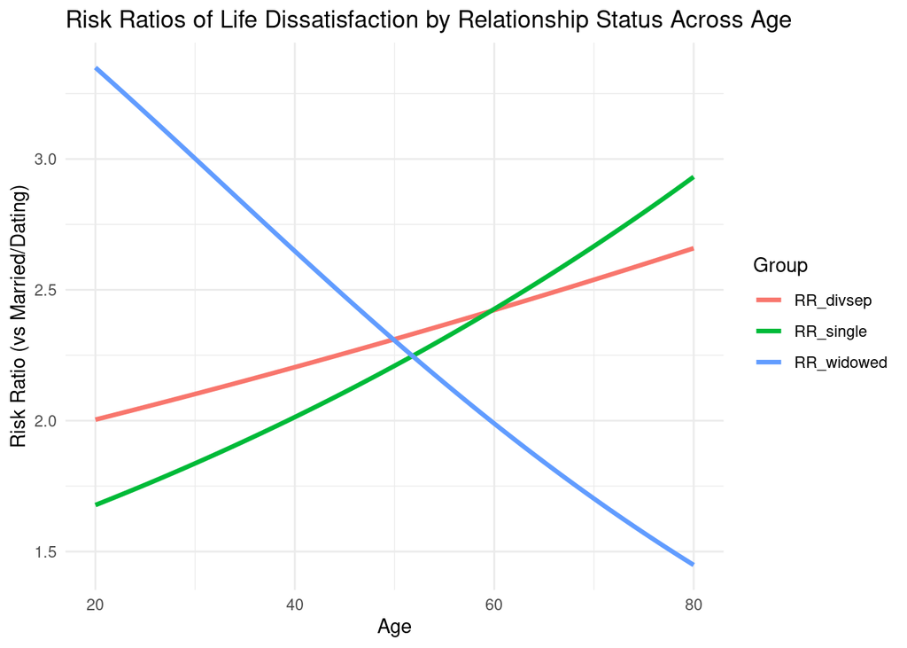

```r
rr_long <- results |>
  select(age, starts_with("RR")) |>
  pivot_longer(-age, names_to = "group", values_to = "RR")

ggplot(rr_long, aes(x = age, y = RR, color = group)) +
  geom_line(size = 1.2) +
  labs(
    title = "Risk Ratios of Life Dissatisfaction by Relationship Status Across Age",
    x = "Age",
    y = "Risk Ratio (vs Married/Dating)",
    color = "Group"
  ) +
  theme_minimal()
```

# Conclusion

> We find that there is a significant relationship between relationship status and reported life satisfaction. As seen in Figure 1, the percentage of respondents in relationships (married/dating) reporting life satisfaction is higher than the percent of those not currently in relationships. In Figure 2, we can see how the risk ratio of respondent dissatisfaction changes over age by relationship group compared to our reference married/dating group. This shows how younger widowed respondents are at the highest risk of dissatisfaction, while single or divorced/seperated respondents are closer to our reference married/dating group. As age increases, widowed respondents show lowering risk while divorced/seperated and single respondents show increasing risk. This increasing risk of dissatisfaction among the divorced/seperated and single groups compared to the married/dating group runs counter to what we see in our exploratory data analysis figure which shows % of respondents reporting life satisfaction increasing among our non-married/dating groups. This suggests that we have correctly identified some confounding variables variables in our modelling.

> From the adjusted survey-weighted regression model, divorced or separated, widowed, and never married/single individuals all show higher odds of reporting life dissatisfaction compared to those who are married or dating. This suggests that relationship status is an important factor associated with self-reported life satisfaction in the U.S. adult population, even after accounting for age, sex, education, income, and number of children.

> We acknowledge a few issues with our analysis, mostly due to dealing with survey data. Because the BRFSS is a survey, we cannot establish causality or determine the direction of the relationship between marital status and life satisfaction. All variables are self-reported, which may introduce reporting bias (although the survey weighting is meant to help address this). In addition, although we adjusted for several key covariates, confounding from other unmeasured variables such as mental health history, social support and friendships, activity level, personal injury history or other life events may still be present and unaccounted for.

> From a public health perspective, these findings suggest that individuals who are not married or in a partnership may represent a group at higher risk of lower life satisfaction and could potentially benefit from targeted social and mental health support programs. In particular, this gap widens as age increases for the divorced/seperated and single groups. Providing older singles social opportunities and creating support networks for them as they age may help improve their mental health and wellbeing. Additionally, we find young widows are at a high risk of life dissatisfaction, though this is likely already a group which is known to be at risk and is provided support under our current healthcare system.

## References

Bi, K., Chen, S., Yip, P. S. F., & Sun, P. (2022). Domains of life satisfaction and perceived health and incidence of chronic illnesses and hospitalization: Evidence from a large population-based Chinese cohort. BMC Public Health, 22(1), 1703. https://doi.org/10.1186/s12889-022-14119-3

Grundström, J., Konttinen, H., Berg, N., & Kiviruusu, O. (2021). Associations between relationship status and mental well-being in different life phases from young to middle adulthood. SSM - Population Health, 14, 100774. https://doi.org/10.1016/j.ssmph.2021.100774

Whisman, M. A., Gilmour, A. L., & Salinger, J. M. (2018). Marital satisfaction and mortality in the United States adult population. Health Psychology, 37(11), 1041–1044. https://doi.org/10.1037/hea0000677